# Orange Juice Purchases

Bruce Hartman

2024-11-06

# Introduction

We will perform some analysis on the Orange Juice purchase data from the `ISLR2` package.

# Packages

Loading the standard packages for this course:

```r
library(tidyverse) # used to manipulate data and plot
library(ISLR2) # package contains the data files
library(ggfortify) # some extra ggplot functions
library(GGally) # pairs ggplot and other options
library(skimr) # nice summaries
library(broom) # neat model summary
library(gt) # nice displays of printed data
library(patchwork) # arranging graphs
library(car) # useful tools for regression analysis
```

# Data

The orange juice data is in the data package.

```r
data(OJ)
if(interactive()) help(OJ)
OJ %>% skim
```

```
── Data Summary ────────────────────────
                           Values
Name                       Piped data
Number of rows             1070
Number of columns          18
_______________________
Column type frequency:
  factor                   2
  numeric                  16
________________________
Group variables            None
```

|  | skim_variable | n_missing | complete_rate | ordered | n_unique | top_counts |
| --- | --- | --- | --- | --- | --- | --- |
| 1 | Purchase | 0 | 1 | FALSE | 2 | CH: 653, MM: 417 |
| 2 | Store7 | 0 | 1 | FALSE | 2 | No: 714, Yes: 356 |

|  | skim_variable | n_missing | complete_rate | mean | sd | p0 | p25 | p50 | p75 | p100 | hist |
| --- | --- | --- | --- | --- | --- | --- | --- | --- | --- | --- | --- |
| 1 | WeekofPurchase | 0 | 1 | 254.38130841 | 15.5582861 | 2.27e+02 | 240.0000000 | 257.00 | 268.0000000 | 278.000000 | ▆▅▅▇▇ |
| 2 | StoreID | 0 | 1 | 3.95981308 | 2.3089835 | 1.00e+00 | 2.0000000 | 3.00 | 7.0000000 | 7.000000 | ▇▅▃▁▇ |
| 3 | PriceCH | 0 | 1 | 1.86742056 | 0.1019698 | 1.69e+00 | 1.7900000 | 1.86 | 1.9900000 | 2.090000 | ▅▂▇▆▁ |
| 4 | PriceMM | 0 | 1 | 2.08541121 | 0.1343855 | 1.69e+00 | 1.9900000 | 2.09 | 2.1800000 | 2.290000 | ▂▁▃▇▆ |
| 5 | DiscCH | 0 | 1 | 0.05185981 | 0.1174742 | 0.00e+00 | 0.0000000 | 0.00 | 0.0000000 | 0.500000 | ▇▁▁▁▁ |
| 6 | DiscMM | 0 | 1 | 0.12336449 | 0.2138337 | 0.00e+00 | 0.0000000 | 0.00 | 0.2300000 | 0.800000 | ▇▁▂▁▁ |
| 7 | SpecialCH | 0 | 1 | 0.14766355 | 0.3549321 | 0.00e+00 | 0.0000000 | 0.00 | 0.0000000 | 1.000000 | ▇▁▁▁▂ |
| 8 | SpecialMM | 0 | 1 | 0.16168224 | 0.3683312 | 0.00e+00 | 0.0000000 | 0.00 | 0.0000000 | 1.000000 | ▇▁▁▁▂ |
| 9 | LoyalCH | 0 | 1 | 0.56578233 | 0.3078425 | 1.10e-05 | 0.3252572 | 0.60 | 0.8508728 | 0.999947 | ▅▃▆▆▇ |
| 10 | SalePriceMM | 0 | 1 | 1.96204673 | 0.2526974 | 1.19e+00 | 1.6900000 | 2.09 | 2.1300000 | 2.290000 | ▁▂▂▂▇ |

[output cut: 6 more lines]

There are 18 columns two of which are factors. There are 1070 rows of purchases. Each purchase is either of CH (Citrus Hill) or MM (Minute Maid) juice. The variable Store7 indicates if it is a purchase at Store 7 or not. All observations are complete. The Store variable is numeric, but indicates which store with an integer from 1 to 7. The purchases are dated to a week given by the WeekOfPurchase variable.

# Data Description

The `skim` output gives us some idea of the data in the dataset. We will describe it further.

```r
OJ %>% glimpse
```

```
Rows: 1,070
Columns: 18
$ Purchase       <fct> CH, CH, CH, MM, CH, CH, CH, CH, CH, CH, CH, CH, CH, CH, CH, CH, MM, MM, M…
$ WeekofPurchase <dbl> 237, 239, 245, 227, 228, 230, 232, 234, 235, 238, 240, 263, 276, 268, 278…
$ StoreID        <dbl> 1, 1, 1, 1, 7, 7, 7, 7, 7, 7, 7, 7, 7, 7, 7, 7, 1, 2, 2, 7, 7, 1, 7, 7, 7…
$ PriceCH        <dbl> 1.75, 1.75, 1.86, 1.69, 1.69, 1.69, 1.69, 1.75, 1.75, 1.75, 1.86, 1.86, 1…
$ PriceMM        <dbl> 1.99, 1.99, 2.09, 1.69, 1.69, 1.99, 1.99, 1.99, 1.99, 1.99, 2.09, 2.13, 2…
$ DiscCH         <dbl> 0.00, 0.00, 0.17, 0.00, 0.00, 0.00, 0.00, 0.00, 0.00, 0.00, 0.00, 0.27, 0…
$ DiscMM         <dbl> 0.00, 0.30, 0.00, 0.00, 0.00, 0.00, 0.40, 0.40, 0.40, 0.40, 0.00, 0.00, 0…
$ SpecialCH      <dbl> 0, 0, 0, 0, 0, 0, 1, 1, 0, 0, 0, 0, 0, 0, 0, 0, 0, 0, 0, 0, 0, 0, 0, 1, 0…
$ SpecialMM      <dbl> 0, 1, 0, 0, 0, 1, 1, 0, 0, 0, 0, 0, 1, 0, 0, 0, 1, 1, 0, 0, 0, 0, 0, 0, 0…
$ LoyalCH        <dbl> 0.500000, 0.600000, 0.680000, 0.400000, 0.956535, 0.965228, 0.972182, 0.9…
$ SalePriceMM    <dbl> 1.99, 1.69, 2.09, 1.69, 1.69, 1.99, 1.59, 1.59, 1.59, 1.59, 2.09, 2.13, 1…
$ SalePriceCH    <dbl> 1.75, 1.75, 1.69, 1.69, 1.69, 1.69, 1.69, 1.75, 1.75, 1.75, 1.86, 1.59, 1…
$ PriceDiff      <dbl> 0.24, -0.06, 0.40, 0.00, 0.00, 0.30, -0.10, -0.16, -0.16, -0.16, 0.23, 0.…
$ Store7         <fct> No, No, No, No, Yes, Yes, Yes, Yes, Yes, Yes, Yes, Yes, Yes, Yes, Yes, Ye…
$ PctDiscMM      <dbl> 0.000000, 0.150754, 0.000000, 0.000000, 0.000000, 0.000000, 0.201005, 0.2…
$ PctDiscCH      <dbl> 0.000000, 0.000000, 0.091398, 0.000000, 0.000000, 0.000000, 0.000000, 0.0…
$ ListPriceDiff  <dbl> 0.24, 0.24, 0.23, 0.00, 0.00, 0.30, 0.30, 0.24, 0.24, 0.24, 0.23, 0.27, 0…
$ STORE          <dbl> 1, 1, 1, 1, 0, 0, 0, 0, 0, 0, 0, 0, 0, 0, 0, 0, 1, 2, 2, 0, 0, 1, 0, 0, 0…
```

This output is handy for seeing variable names and types, and the size of the dataset, and some example entries.

Let’s create a way to page through all the actual data.

```r
OJ
```

|  | Purchase | WeekofPurchase | StoreID | PriceCH | PriceMM | DiscCH | DiscMM | SpecialCH | SpecialMM | LoyalCH | SalePriceMM | SalePriceCH | PriceDiff | Store7 | PctDiscMM | PctDiscCH | ListPriceDiff | STORE |
| --- | --- | --- | --- | --- | --- | --- | --- | --- | --- | --- | --- | --- | --- | --- | --- | --- | --- | --- |
| 1 | CH | 237 | 1 | 1.75 | 1.99 | 0.00 | 0.00 | 0 | 0 | 0.500000 | 1.99 | 1.75 | 0.24 | No | 0.000000 | 0.000000 | 0.24 | 1 |
| 2 | CH | 239 | 1 | 1.75 | 1.99 | 0.00 | 0.30 | 0 | 1 | 0.600000 | 1.69 | 1.75 | -0.06 | No | 0.150754 | 0.000000 | 0.24 | 1 |
| 3 | CH | 245 | 1 | 1.86 | 2.09 | 0.17 | 0.00 | 0 | 0 | 0.680000 | 2.09 | 1.69 | 0.40 | No | 0.000000 | 0.091398 | 0.23 | 1 |
| 4 | MM | 227 | 1 | 1.69 | 1.69 | 0.00 | 0.00 | 0 | 0 | 0.400000 | 1.69 | 1.69 | 0.00 | No | 0.000000 | 0.000000 | 0.00 | 1 |
| 5 | CH | 228 | 7 | 1.69 | 1.69 | 0.00 | 0.00 | 0 | 0 | 0.956535 | 1.69 | 1.69 | 0.00 | Yes | 0.000000 | 0.000000 | 0.00 | 0 |
| 6 | CH | 230 | 7 | 1.69 | 1.99 | 0.00 | 0.00 | 0 | 1 | 0.965228 | 1.99 | 1.69 | 0.30 | Yes | 0.000000 | 0.000000 | 0.30 | 0 |
| 7 | CH | 232 | 7 | 1.69 | 1.99 | 0.00 | 0.40 | 1 | 1 | 0.972182 | 1.59 | 1.69 | -0.10 | Yes | 0.201005 | 0.000000 | 0.30 | 0 |
| 8 | CH | 234 | 7 | 1.75 | 1.99 | 0.00 | 0.40 | 1 | 0 | 0.977746 | 1.59 | 1.75 | -0.16 | Yes | 0.201005 | 0.000000 | 0.24 | 0 |
| 9 | CH | 235 | 7 | 1.75 | 1.99 | 0.00 | 0.40 | 0 | 0 | 0.982197 | 1.59 | 1.75 | -0.16 | Yes | 0.201005 | 0.000000 | 0.24 | 0 |
| 10 | CH | 238 | 7 | 1.75 | 1.99 | 0.00 | 0.40 | 0 | 0 | 0.985757 | 1.59 | 1.75 | -0.16 | Yes | 0.201005 | 0.000000 | 0.24 | 0 |

[output cut: 990 more lines]

The display lets you page through the data and scroll left and right to all the columns.

This summary is the old way of getting ranges of variables. It is sometimes handy.

```r
OJ %>% summary
```

```
 Purchase WeekofPurchase     StoreID        PriceCH         PriceMM          DiscCH
 CH:653   Min.   :227.0   Min.   :1.00   Min.   :1.690   Min.   :1.690   Min.   :0.00000
 MM:417   1st Qu.:240.0   1st Qu.:2.00   1st Qu.:1.790   1st Qu.:1.990   1st Qu.:0.00000
          Median :257.0   Median :3.00   Median :1.860   Median :2.090   Median :0.00000
          Mean   :254.4   Mean   :3.96   Mean   :1.867   Mean   :2.085   Mean   :0.05186
          3rd Qu.:268.0   3rd Qu.:7.00   3rd Qu.:1.990   3rd Qu.:2.180   3rd Qu.:0.00000
          Max.   :278.0   Max.   :7.00   Max.   :2.090   Max.   :2.290   Max.   :0.50000
     DiscMM         SpecialCH        SpecialMM         LoyalCH          SalePriceMM
 Min.   :0.0000   Min.   :0.0000   Min.   :0.0000   Min.   :0.000011   Min.   :1.190
 1st Qu.:0.0000   1st Qu.:0.0000   1st Qu.:0.0000   1st Qu.:0.325257   1st Qu.:1.690
 Median :0.0000   Median :0.0000   Median :0.0000   Median :0.600000   Median :2.090
 Mean   :0.1234   Mean   :0.1477   Mean   :0.1617   Mean   :0.565782   Mean   :1.962
 3rd Qu.:0.2300   3rd Qu.:0.0000   3rd Qu.:0.0000   3rd Qu.:0.850873   3rd Qu.:2.130
 Max.   :0.8000   Max.   :1.0000   Max.   :1.0000   Max.   :0.999947   Max.   :2.290
  SalePriceCH      PriceDiff       Store7      PctDiscMM        PctDiscCH       ListPriceDiff
 Min.   :1.390   Min.   :-0.6700   No :714   Min.   :0.0000   Min.   :0.00000   Min.   :0.000
 1st Qu.:1.750   1st Qu.: 0.0000   Yes:356   1st Qu.:0.0000   1st Qu.:0.00000   1st Qu.:0.140
 Median :1.860   Median : 0.2300             Median :0.0000   Median :0.00000   Median :0.240
 Mean   :1.816   Mean   : 0.1465             Mean   :0.0593   Mean   :0.02731   Mean   :0.218
 3rd Qu.:1.890   3rd Qu.: 0.3200             3rd Qu.:0.1127   3rd Qu.:0.00000   3rd Qu.:0.300
 Max.   :2.090   Max.   : 0.6400             Max.   :0.4020   Max.   :0.25269   Max.   :0.440
     STORE
 Min.   :0.000
 1st Qu.:0.000
 Median :2.000
 Mean   :1.631
 3rd Qu.:3.000
 Max.   :4.000
```

# Data Wrangling

Purchase and Store7 are already factor variables. R is very good at handling factors, which remember the data, but also encode it into small numbers like 0 and 1 for analysis. But there are several others that have only a few values.

- Store7 for instance should be a factor; it’s just Yes/No.
- STORE just indicates which of 5 stores numbered 0 through 4 the purchase was made at. It should be a factor.
- SpecialCH and SpecialMM seem to be binary (0-1) variables indicating whether there was a special on that brand at the time of thepurchase.

We will make a new data frame OJ1 with the modifications.

```r
OJ1 = OJ %>% mutate(Store7 = factor(Store7),
                    STORE = factor(STORE),
                    SpecialCH = factor(SpecialCH),
                    SpecialMM = factor(SpecialMM))
OJ1 %>% glimpse
```

```
Rows: 1,070
Columns: 18
$ Purchase       <fct> CH, CH, CH, MM, CH, CH, CH, CH, CH, CH, CH, CH, CH, CH, CH, CH, MM, MM, M…
$ WeekofPurchase <dbl> 237, 239, 245, 227, 228, 230, 232, 234, 235, 238, 240, 263, 276, 268, 278…
$ StoreID        <dbl> 1, 1, 1, 1, 7, 7, 7, 7, 7, 7, 7, 7, 7, 7, 7, 7, 1, 2, 2, 7, 7, 1, 7, 7, 7…
$ PriceCH        <dbl> 1.75, 1.75, 1.86, 1.69, 1.69, 1.69, 1.69, 1.75, 1.75, 1.75, 1.86, 1.86, 1…
$ PriceMM        <dbl> 1.99, 1.99, 2.09, 1.69, 1.69, 1.99, 1.99, 1.99, 1.99, 1.99, 2.09, 2.13, 2…
$ DiscCH         <dbl> 0.00, 0.00, 0.17, 0.00, 0.00, 0.00, 0.00, 0.00, 0.00, 0.00, 0.00, 0.27, 0…
$ DiscMM         <dbl> 0.00, 0.30, 0.00, 0.00, 0.00, 0.00, 0.40, 0.40, 0.40, 0.40, 0.00, 0.00, 0…
$ SpecialCH      <fct> 0, 0, 0, 0, 0, 0, 1, 1, 0, 0, 0, 0, 0, 0, 0, 0, 0, 0, 0, 0, 0, 0, 0, 1, 0…
$ SpecialMM      <fct> 0, 1, 0, 0, 0, 1, 1, 0, 0, 0, 0, 0, 1, 0, 0, 0, 1, 1, 0, 0, 0, 0, 0, 0, 0…
$ LoyalCH        <dbl> 0.500000, 0.600000, 0.680000, 0.400000, 0.956535, 0.965228, 0.972182, 0.9…
$ SalePriceMM    <dbl> 1.99, 1.69, 2.09, 1.69, 1.69, 1.99, 1.59, 1.59, 1.59, 1.59, 2.09, 2.13, 1…
$ SalePriceCH    <dbl> 1.75, 1.75, 1.69, 1.69, 1.69, 1.69, 1.69, 1.75, 1.75, 1.75, 1.86, 1.59, 1…
$ PriceDiff      <dbl> 0.24, -0.06, 0.40, 0.00, 0.00, 0.30, -0.10, -0.16, -0.16, -0.16, 0.23, 0.…
$ Store7         <fct> No, No, No, No, Yes, Yes, Yes, Yes, Yes, Yes, Yes, Yes, Yes, Yes, Yes, Ye…
$ PctDiscMM      <dbl> 0.000000, 0.150754, 0.000000, 0.000000, 0.000000, 0.000000, 0.201005, 0.2…
$ PctDiscCH      <dbl> 0.000000, 0.000000, 0.091398, 0.000000, 0.000000, 0.000000, 0.000000, 0.0…
$ ListPriceDiff  <dbl> 0.24, 0.24, 0.23, 0.00, 0.00, 0.30, 0.30, 0.24, 0.24, 0.24, 0.23, 0.27, 0…
$ STORE          <fct> 1, 1, 1, 1, 0, 0, 0, 0, 0, 0, 0, 0, 0, 0, 0, 0, 1, 2, 2, 0, 0, 1, 0, 0, 0…
```

- StoreID is a number between 1 and 7. But are all values allowed? Or is this variable just like STORE, with just 5 values. Are these columns redundant?

We could just display them side by side and manually check.

```r
OJ1 %>% select(STORE, StoreID)
```

|  | STORE | StoreID |
| --- | --- | --- |
| 1 | 1 | 1 |
| 2 | 1 | 1 |
| 3 | 1 | 1 |
| 4 | 1 | 1 |
| 5 | 0 | 7 |
| 6 | 0 | 7 |
| 7 | 0 | 7 |
| 8 | 0 | 7 |
| 9 | 0 | 7 |
| 10 | 0 | 7 |

[output cut: 990 more lines]

But this is boring and prone to errors!! An easy check is to make a ‘crosstab’ table.

```r
OJ1 %>% select(StoreID, STORE) %>% table
```

```
       STORE
StoreID   0   1   2   3   4
      1   0 157   0   0   0
      2   0   0 222   0   0
      3   0   0   0 196   0
      4   0   0   0   0 139
      7 356   0   0   0   0
```

You can see that the values in STORE and StoreID line up perfectly, with Store 7 encoded as 0 in STORE. Store 7 is obviously very busy with purchases. So we probably don’t need both variables.

We are using StoreID elsewhere with the indicator variable Store7. Let’s check that purchases with StoreID=7 actually have Store7 set to Yes, and the others not.

```r
OJ1 %>% select(StoreID, Store7) %>% table
```

```
       Store7
StoreID  No Yes
      1 157   0
      2 222   0
      3 196   0
      4 139   0
      7   0 356
```

Perfect match.

Can we reproduce the STORE variable by making StoreID a factor?

```r
f_StoreID = OJ1 %>% pull(StoreID) %>% factor
table(OJ1$STORE, f_StoreID)
```

```
   f_StoreID
      1   2   3   4   7
  0   0   0   0   0 356
  1 157   0   0   0   0
  2   0 222   0   0   0
  3   0   0 196   0   0
  4   0   0   0 139   0
```

```r
table(OJ1$StoreID, f_StoreID)
```

```
   f_StoreID
      1   2   3   4   7
  1 157   0   0   0   0
  2   0 222   0   0   0
  3   0   0 196   0   0
  4   0   0   0 139   0
  7   0   0   0   0 356
```

f_StoreID is identical to StoreID. So we will make StoreID a factor.

```r
OJ1 = OJ1 %>%  mutate(StoreID = factor(StoreID))
OJ1 %>% glimpse
```

```
Rows: 1,070
Columns: 18
$ Purchase       <fct> CH, CH, CH, MM, CH, CH, CH, CH, CH, CH, CH, CH, CH, CH, CH, CH, MM, MM, M…
$ WeekofPurchase <dbl> 237, 239, 245, 227, 228, 230, 232, 234, 235, 238, 240, 263, 276, 268, 278…
$ StoreID        <fct> 1, 1, 1, 1, 7, 7, 7, 7, 7, 7, 7, 7, 7, 7, 7, 7, 1, 2, 2, 7, 7, 1, 7, 7, 7…
$ PriceCH        <dbl> 1.75, 1.75, 1.86, 1.69, 1.69, 1.69, 1.69, 1.75, 1.75, 1.75, 1.86, 1.86, 1…
$ PriceMM        <dbl> 1.99, 1.99, 2.09, 1.69, 1.69, 1.99, 1.99, 1.99, 1.99, 1.99, 2.09, 2.13, 2…
$ DiscCH         <dbl> 0.00, 0.00, 0.17, 0.00, 0.00, 0.00, 0.00, 0.00, 0.00, 0.00, 0.00, 0.27, 0…
$ DiscMM         <dbl> 0.00, 0.30, 0.00, 0.00, 0.00, 0.00, 0.40, 0.40, 0.40, 0.40, 0.00, 0.00, 0…
$ SpecialCH      <fct> 0, 0, 0, 0, 0, 0, 1, 1, 0, 0, 0, 0, 0, 0, 0, 0, 0, 0, 0, 0, 0, 0, 0, 1, 0…
$ SpecialMM      <fct> 0, 1, 0, 0, 0, 1, 1, 0, 0, 0, 0, 0, 1, 0, 0, 0, 1, 1, 0, 0, 0, 0, 0, 0, 0…
$ LoyalCH        <dbl> 0.500000, 0.600000, 0.680000, 0.400000, 0.956535, 0.965228, 0.972182, 0.9…
$ SalePriceMM    <dbl> 1.99, 1.69, 2.09, 1.69, 1.69, 1.99, 1.59, 1.59, 1.59, 1.59, 2.09, 2.13, 1…
$ SalePriceCH    <dbl> 1.75, 1.75, 1.69, 1.69, 1.69, 1.69, 1.69, 1.75, 1.75, 1.75, 1.86, 1.59, 1…
$ PriceDiff      <dbl> 0.24, -0.06, 0.40, 0.00, 0.00, 0.30, -0.10, -0.16, -0.16, -0.16, 0.23, 0.…
$ Store7         <fct> No, No, No, No, Yes, Yes, Yes, Yes, Yes, Yes, Yes, Yes, Yes, Yes, Yes, Ye…
$ PctDiscMM      <dbl> 0.000000, 0.150754, 0.000000, 0.000000, 0.000000, 0.000000, 0.201005, 0.2…
$ PctDiscCH      <dbl> 0.000000, 0.000000, 0.091398, 0.000000, 0.000000, 0.000000, 0.000000, 0.0…
$ ListPriceDiff  <dbl> 0.24, 0.24, 0.23, 0.00, 0.00, 0.30, 0.30, 0.24, 0.24, 0.24, 0.23, 0.27, 0…
$ STORE          <fct> 1, 1, 1, 1, 0, 0, 0, 0, 0, 0, 0, 0, 0, 0, 0, 0, 1, 2, 2, 0, 0, 1, 0, 0, 0…
```

# Data Visualization

Let’s visualize the data with a ggpairs plot. But it will be very busy. So let’s breakit up into the numeric and the factor variables. Let’s do just the numeric variables to get correlations and dot plots.

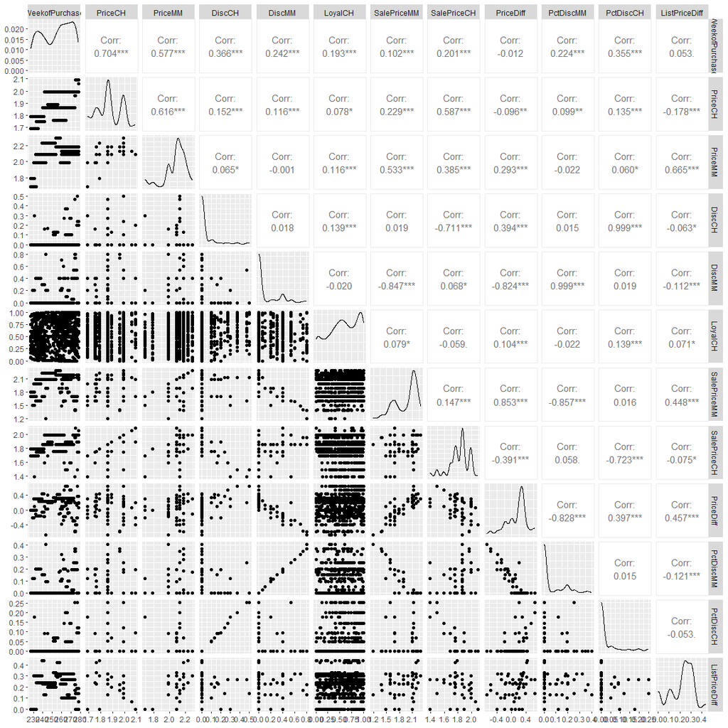

```r
OJ1 %>% select(where(is.numeric)) %>% ggpairs(progress=F)
```

Now let’s do only the non-numeric variables.

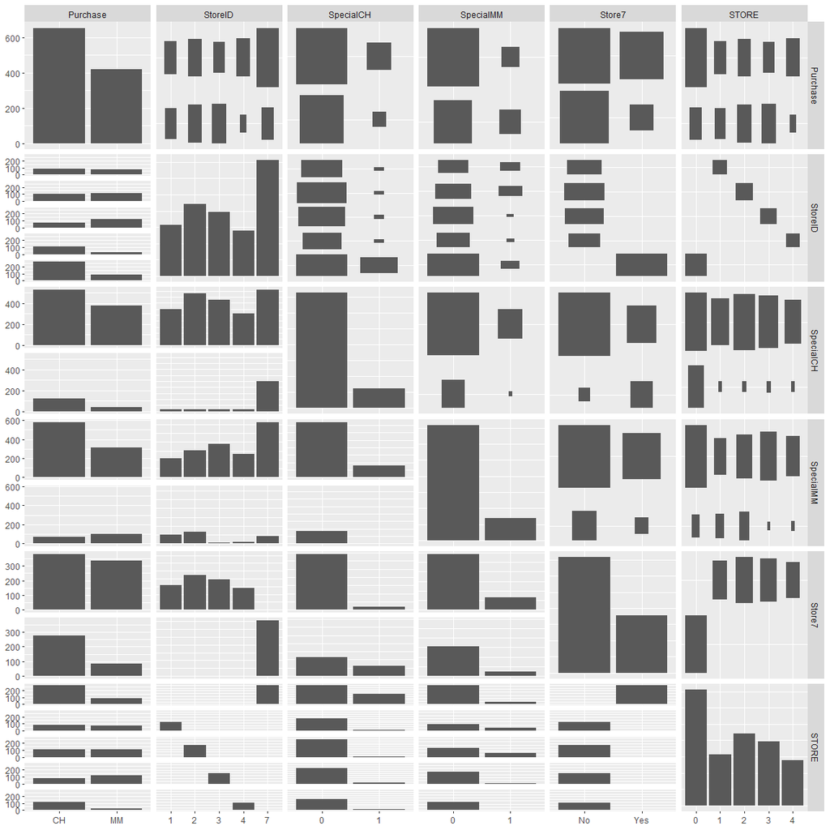

```r
OJ1 %>% select(-where(is.numeric)) %>% ggpairs(progress=F)
```

# More Viz

Let’s compare sale prices of the two products for each purchase.

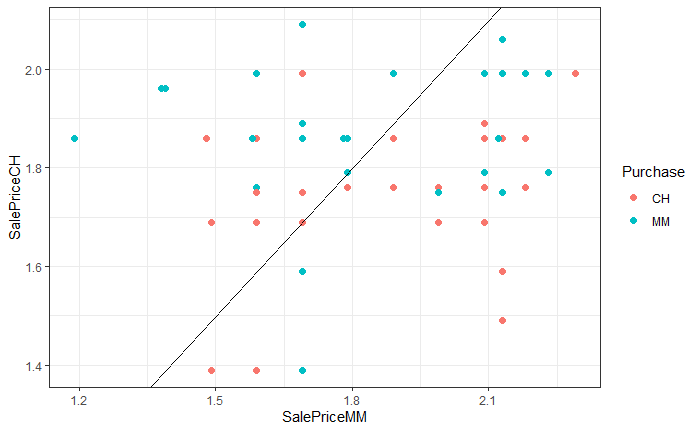

```r
OJ1 %>% ggplot(aes(SalePriceMM, SalePriceCH)) +
  geom_point(aes(SalePriceMM, SalePriceCH, color=Purchase), size=2) +
  geom_abline(aes(slope=1, intercept=0))+
  theme_bw()
```

Lets try the same graph with the discount percents at the time of purchase.

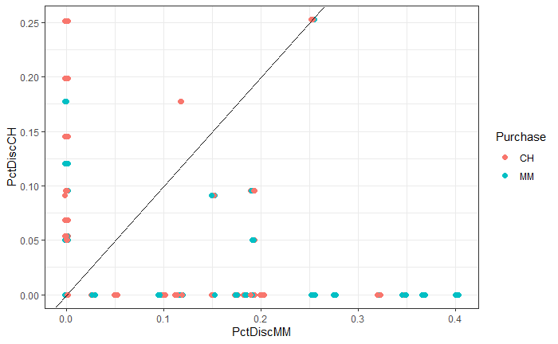

```r
# OJ1 %>% glimpse
OJ1 %>% ggplot(aes(PctDiscMM, PctDiscCH)) +
  geom_point(aes(PctDiscMM, PctDiscCH, color=Purchase), size=2,
             position="jitter") +
  geom_abline(aes(slope=1, intercept=0))+
  theme_bw()
```

This graph reveals that **discounts matter a lot**. While some purchases of CH are made even when there is a discount on MM but not CH, and vice versa, there are also many purchases of the product at a discount.

Let’s compare purchase prices when there is a special.

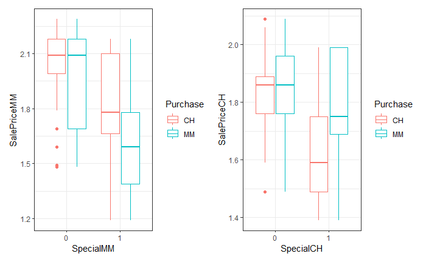

```r
bCH = ggplot(OJ1) +
  geom_boxplot(aes(SpecialMM, SalePriceMM, color=Purchase)) +
  theme_bw()
bMM =ggplot(OJ1) +
  geom_boxplot(aes(SpecialCH, SalePriceCH, color=Purchase)) +
  theme_bw()

bCH | bMM
```

Interesting?

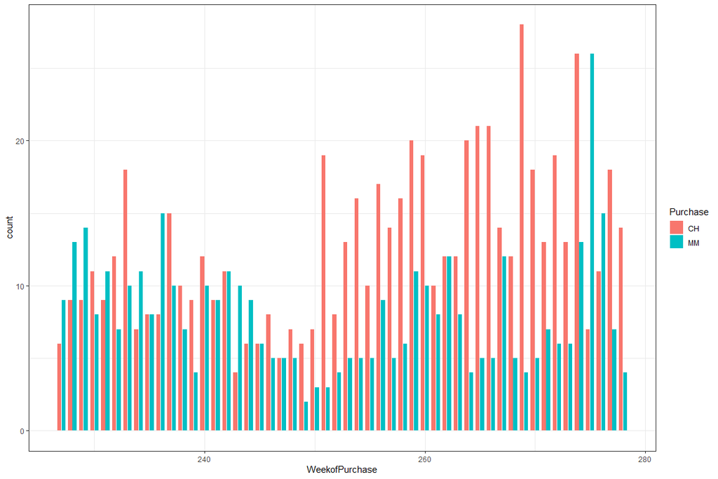

```r
ggplot(OJ1) +
  geom_bar(aes(WeekofPurchase, fill=Purchase), position=position_dodge2(), width=.80) +
  theme_bw()
```

# Research Problem

```r
# OJ1 %>% glimpse
OJ1 %>% group_by(WeekofPurchase) %>% summarize(nP=n(PriceCH))
```

[output not shown]